# AIDS Drug

Jacob Welsh

16 April 2020

# Introduction

A new preventative aides (triUmpsal) is under test in clinical trials. Analyze the effectiveness of this drug across the board. Consider population subgroups by gender, drug use, and sexual orientation. Finish this!

# Methods

All questions are categorical-categorical, as a result we will use the same methods for graphical descriptions, numerical descriptions, and inferences.  
Graphical Descriptions will be Bar Charts.  
Numerical Descriptions will be cross tables.  
Inferentials wil; be a chi-square test and/or fisher test exact test.

The conclusion for all the questions will be described at the end.

This is true for all 5 questions.

## Question 1 : Is the drug effective in the general population?

$H_0$ : The drug has no effect on whether or not one gets AIDS.

$H_A$ : The drug does have an effect on whether or not one gets AIDS.

### Descriptive Results

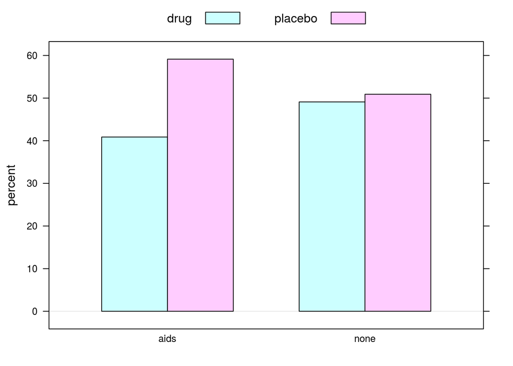

```r
barchartGC(~infected + treatment,data=triUmp, type ="percent")
```

The barchart shows that the vaccine may have an effect whether one aquires aids or not. The percentage for those that got AIDS was lower than those with the placebo.

### Numerical Descriptive Results

```r
table1 <- xtabs(~infected + treatment, data=triUmp)

rowPerc(table1)
```

```
##         treatment
## infected   drug placebo  Total
##     aids  40.87   59.13 100.00
##     none  49.10   50.90 100.00
```

```r
colPerc(table1)
```

```
##         treatment
## infected   drug placebo
##    aids    3.99    5.49
##    none   96.01   94.51
##    Total 100.00  100.00
```

This is a table of column percentages, it shows that of the people on the drug, 3.99 percent contracted AIDS, and 96.01 did not. 5.49 percent of people on the placebo contracted AIDS, while 94.51 percent did not contract the disease.

### Inferential Results

```r
chisq.test(table1)
```

```
##
##  Pearson's Chi-squared test with Yates' continuity correction
##
## data:  table1
## X-squared = 26.41, df = 1, p-value = 2.761e-07
```

```r
chisqtestGC(table1)
```

```
## Pearson's Chi-squared test with Yates' continuity correction
##
## Observed Counts:
##         treatment
## infected  drug placebo
##     aids   423     612
##     none 10168   10540
##
## Counts Expected by Null:
##         treatment
## infected     drug  placebo
##     aids   504.15   530.85
##     none 10086.85 10621.15
##
## Contributions to the chi-square statistic:
##         treatment
## infected  drug placebo
##     aids 13.06   12.40
##     none  0.65    0.62
##
##
## Chi-Square Statistic = 26.4104
## Degrees of Freedom of the table = 1
## P-Value = 0
```

```r
fisher.test(table1)
```

```
##
##  Fisher's Exact Test for Count Data
##
## data:  table1
## p-value = 2.333e-07
## alternative hypothesis: true odds ratio is not equal to 1
## 95 percent confidence interval:
##  0.6295438 0.8148378
## sample estimates:
## odds ratio
##  0.7164774
```

## Question 2 Is the drug effective in the LGBTQ population?

$H_0$: The drug has no effect on members in the LGBTQ population contracting AIDS.

$H_A$: The drug does have some effect in the LGBTQ population contracting AIDS.

### Descriptive Results

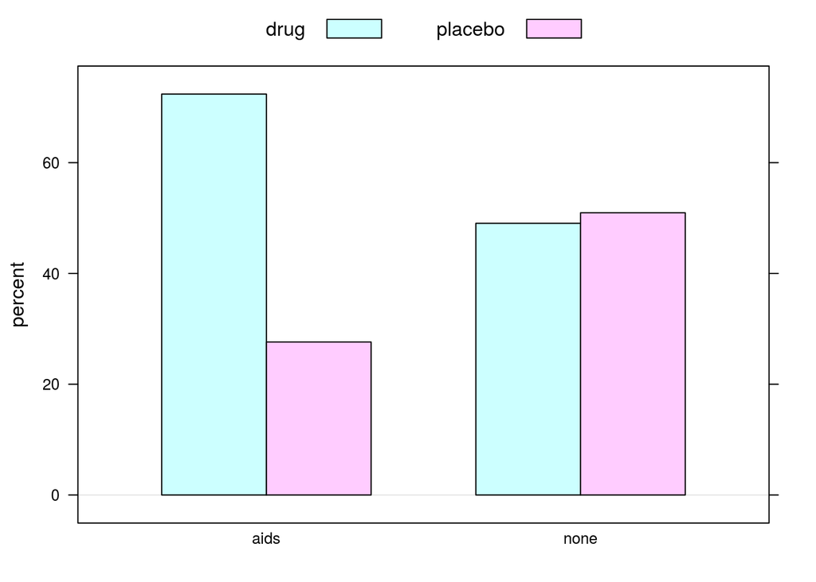

```r
LGBTQdata = filter(triUmp, LGBTQ != "straight")

barchartGC(~infected + treatment,data=LGBTQdata , type ="percent")
```

### Numerical Results

```r
table2 <- xtabs(~infected + treatment, data=LGBTQdata)

rowPerc(table2)
```

```
##         treatment
## infected   drug placebo  Total
##     aids  72.38   27.62 100.00
##     none  49.05   50.95 100.00
```

This is row percentages, it shows that among people who contracted AIDS, 72.38% were on the drug, while 27.62% of them were on the placebo. This also shows that it is pretty even on those not infected,49.05% of them came from the drug group, and 50.95% came from the placebo group.

```r
colPerc(table2)
```

```
##         treatment
## infected   drug placebo
##    aids    7.02     2.7
##    none   92.98    97.3
##    Total 100.00   100.0
```

This is a table of column percentages, it shows that of people that recieved the drug, 7.02 percent contracted AIDS, while 92.98 percent remained clean. It shows that of those on the placebo 2.7% contracted AIDS and 97.3% did not contract the disease.

### Inferential Results

```r
chisq.test(table2)
```

```
##
##  Pearson's Chi-squared test with Yates' continuity correction
##
## data:  table2
## X-squared = 20.826, df = 1, p-value = 5.029e-06
```

```r
chisqtestGC(table2)
```

```
## Pearson's Chi-squared test with Yates' continuity correction
##
## Observed Counts:
##         treatment
## infected drug placebo
##     aids   76      29
##     none 1007    1046
##
## Counts Expected by Null:
##         treatment
## infected    drug placebo
##     aids   52.69   52.31
##     none 1030.31 1022.69
##
## Contributions to the chi-square statistic:
##         treatment
## infected  drug placebo
##     aids 10.31   10.38
##     none  0.53    0.53
##
##
## Chi-Square Statistic = 20.8264
## Degrees of Freedom of the table = 1
## P-Value = 0
```

```r
fisher.test(table2)
```

```
##
##  Fisher's Exact Test for Count Data
##
## data:  table2
## p-value = 2.998e-06
## alternative hypothesis: true odds ratio is not equal to 1
## 95 percent confidence interval:
##  1.735490 4.369508
## sample estimates:
## odds ratio
##   2.720997
```

Pearson’s Chi-squared test has p-value = 5.029e-06, or .000005029. Because this number is smaller than .05, we will reject our null hypothesis. This means the drug DOES have an effect on the LGBTQ population, as seen above however, it is adverse and the drug increases the odds of contracting AIDS. The Fisher’s test gives you the odds of being 2.7 times more likely to contract the disease.

## Question 3 Is the drug effective in the female population?

$H_0$: The drug has no effect on whether or not females contract AIDS.

$H_A$: The drug does have some effect on whether or not females contract AIDS?

### Descriptive Results

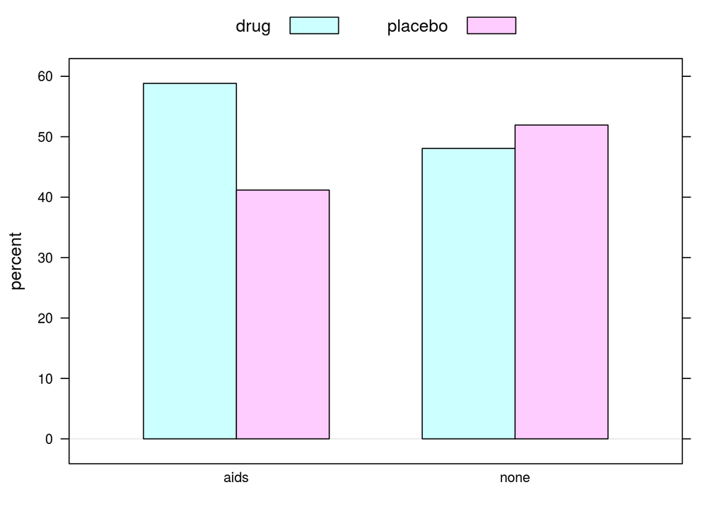

```r
FemalesData = filter(triUmp, gender == 'F')
barchartGC(~infected + treatment,data=FemalesData, type ="percent")
```

### Numerical Results

```r
table3 <- xtabs(~infected + treatment, data=FemalesData)

rowPerc(table3)
```

```
##         treatment
## infected   drug placebo  Total
##     aids  58.82   41.18 100.00
##     none  48.06   51.94 100.00
```

This is row percentages, it shows that of those who contracted AIDS 58.82% were on the test drug while the other 41.18% were on the placebo, which makes the drug look a little bad. Among those who did not contract AIDS it was once again fairly close, 48.06% were on the drug, with 51.94% being on the placebo.

```r
colPerc(table3)
```

```
##         treatment
## infected   drug placebo
##    aids    3.69    2.42
##    none   96.31   97.58
##    Total 100.00  100.00
```

This is a table of column percentages, it shows that among those on tge drug, only 3.69% contracted AIDS, while 2.42% of those on the placebo contracted the disease. The drug group escaped contracting the disease 96.31% of the time, while those on the placebo avoided it 97.58% of the time. ### Inferential Results

```r
chisq.test(table3)
```

```
##
##  Pearson's Chi-squared test with Yates' continuity correction
##
## data:  table3
## X-squared = 15.634, df = 1, p-value = 7.686e-05
```

```r
chisqtestGC(table3)
```

```
## Pearson's Chi-squared test with Yates' continuity correction
##
## Observed Counts:
##         treatment
## infected drug placebo
##     aids  210     147
##     none 5484    5927
##
## Counts Expected by Null:
##         treatment
## infected    drug placebo
##     aids  172.74  184.26
##     none 5521.26 5889.74
##
## Contributions to the chi-square statistic:
##         treatment
## infected drug placebo
##     aids 8.04    7.54
##     none 0.25    0.24
##
##
## Chi-Square Statistic = 15.6339
## Degrees of Freedom of the table = 1
## P-Value = 1e-04
```

```r
fisher.test(table3)
```

```
##
##  Fisher's Exact Test for Count Data
##
## data:  table3
## p-value = 6.596e-05
## alternative hypothesis: true odds ratio is not equal to 1
## 95 percent confidence interval:
##  1.240408 1.925729
## sample estimates:
## odds ratio
##   1.543902
```

According the Chi-squared test the p-value = 7.686e-05, or .00007686, this small of a number means we are going to reject our null hypothesis, that this has no effect on the female population. There seems to be an effect in that females become a little bit more likely to catch the disease. The Fisher’s exact test gives them a 1.5x more likely chance.

## Question 4 Is the drug effective in the male poplulation?

$H_0$: The drug has no effect on members in the male population.

$H_A$: The drug does have some effect in the male population.

### Descriptive Results

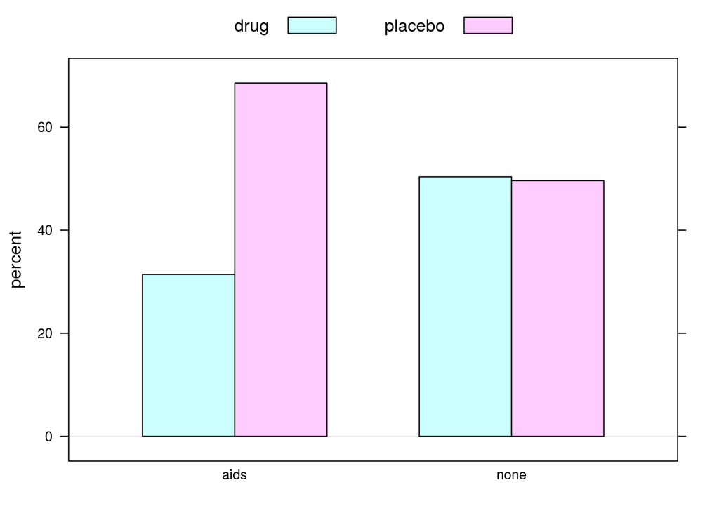

```r
MalesData = filter(triUmp, gender == 'M')
barchartGC(~infected + treatment,data=MalesData, type ="percent")
```

At the first look of this barchart, it would seem the drug has a significant positive effect on the male population, of the males the contracted AIDS. only aroud 30% seem to have come from the group that contained the test drug.

### Numerical Results

```r
table4 <- xtabs(~infected + treatment, data=MalesData)

rowPerc(table4)
```

```
##         treatment
## infected   drug placebo  Total
##     aids  31.42   68.58 100.00
##     none  50.38   49.62 100.00
```

This is row percentages, it shows that the of those who contracted AIDS, only 31.42% contracted AIDS in the group given the drug and 68.58% of the infected came from the placebo group. For the people who did not contract AIDS, as seen in all previous questions it is about the same, 50.38% were on the drug, 49.62% were not. So far it looks pretty good for the male population.

```r
colPerc(table4)
```

```
##         treatment
## infected   drug placebo
##    aids    4.35    9.16
##    none   95.65   90.84
##    Total 100.00  100.00
```

This is a table of column percentages, it shows that of the people on the drug, 4.35% contracted AIDS, while the other 95.65% did not. It also shows that of the people on the placebo group, 9.16% contracted AIDS, while 90.84% did not. Again, looks good for the men, with the higher contraction being on the placebo side.

### Inferential Results

```r
chisq.test(table4)
```

```
##
##  Pearson's Chi-squared test with Yates' continuity correction
##
## data:  table4
## X-squared = 90.194, df = 1, p-value < 2.2e-16
```

```r
chisqtestGC(table4)
```

```
## Pearson's Chi-squared test with Yates' continuity correction
##
## Observed Counts:
##         treatment
## infected drug placebo
##     aids  213     465
##     none 4684    4613
##
## Counts Expected by Null:
##         treatment
## infected    drug placebo
##     aids  332.85  345.15
##     none 4564.15 4732.85
##
## Contributions to the chi-square statistic:
##         treatment
## infected  drug placebo
##     aids 43.15   41.62
##     none  3.15    3.03
##
##
## Chi-Square Statistic = 90.1943
## Degrees of Freedom of the table = 1
## P-Value = 0
```

```r
fisher.test(table4)
```

```
##
##  Fisher's Exact Test for Count Data
##
## data:  table4
## p-value < 2.2e-16
## alternative hypothesis: true odds ratio is not equal to 1
## 95 percent confidence interval:
##  0.3798342 0.5345407
## sample estimates:
## odds ratio
##  0.4511536
```

With the p-value in the Chi test being somewhere around 0000000000000002.2 we are rejecting this null hypothesis, the drug most certainly has an effect on the male population in that less of them contract the disease. In the Fisher Exact test, you have odds of being half less likely to contract AIDS.

## Question 5 Is the drug effective in the drug using community?

$H_0$: The drug has no effect on members in the drug using community.

$H_A$: The drug does have some effect in the drug using community.

### Descriptive Results

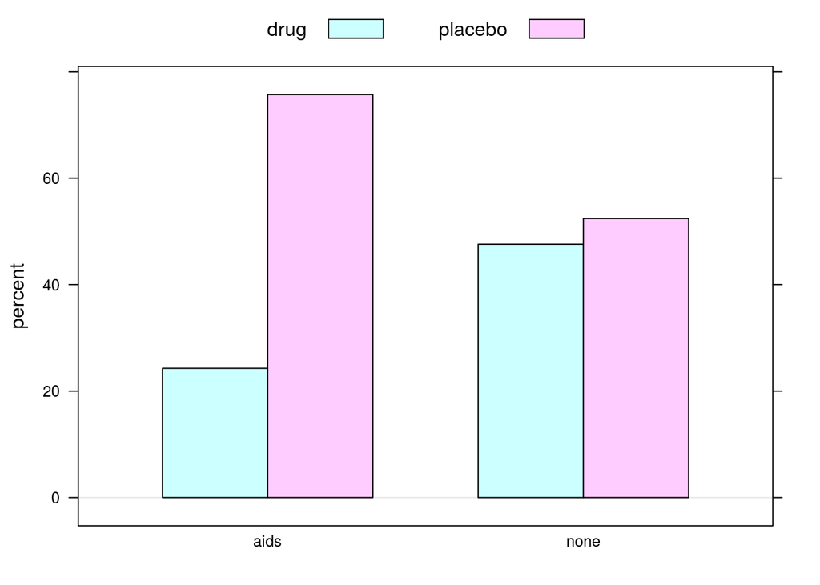

```r
DrugUserData = filter(triUmp, DrugUser == "yes")
barchartGC(~infected + treatment,data=DrugUserData, type ="percent")
```

This barchart is showing some strong positive effect from the drug, here it would seem that among those who contracted AIDS it looks to be about 25% came from those on the test drug, while the other 75% came from the placebo group. Those who did not contract are again about even between groups.

### Numerical Results

```r
table5 <- xtabs(~infected + treatment, data=DrugUserData)

rowPerc(table5)
```

```
##         treatment
## infected   drug placebo  Total
##     aids  24.29   75.71 100.00
##     none  47.59   52.41 100.00
```

This is row percentages, it shows that of all those who contracted AIDS, only 24.29% came from the test drug group, while 75.71% came from the placebo group, this shows a strong positive effect. Among those who did not contract AIDS 47.59% came from the group on the test drug, with the other 52.41% being from the placebo.

```r
colPerc(table5)
```

```
##         treatment
## infected   drug placebo
##    aids    2.89    7.77
##    none   97.11   92.23
##    Total 100.00  100.00
```

This is a table of column percentages, it shows that of the people on the drug, 2.89% contracted the disease, while 97.11% did not. For the placebo group 7.77% were infected, while 92.23% did go clean. This shows again the the drug is in fact having an effect.

### Inferential Results

```r
chisq.test(table5)
```

```
##
##  Pearson's Chi-squared test with Yates' continuity correction
##
## data:  table5
## X-squared = 27.955, df = 1, p-value = 1.242e-07
```

```r
chisqtestGC(table5)
```

```
## Pearson's Chi-squared test with Yates' continuity correction
##
## Observed Counts:
##         treatment
## infected drug placebo
##     aids   34     106
##     none 1143    1259
##
## Counts Expected by Null:
##         treatment
## infected    drug placebo
##     aids   64.82   75.18
##     none 1112.18 1289.82
##
## Contributions to the chi-square statistic:
##         treatment
## infected  drug placebo
##     aids 14.66   12.64
##     none  0.85    0.74
##
##
## Chi-Square Statistic = 27.955
## Degrees of Freedom of the table = 1
## P-Value = 0
```

```r
fisher.test(table5)
```

```
##
##  Fisher's Exact Test for Count Data
##
## data:  table5
## p-value = 4.23e-08
## alternative hypothesis: true odds ratio is not equal to 1
## 95 percent confidence interval:
##  0.2308342 0.5294225
## sample estimates:
## odds ratio
##  0.3534128
```

The Chi-squared test give us a p-value = 1.242e-07, or .0000001245. This small number means we reject the null hypothesis. There is what seems to be a strong positive effect from the test drug on the group of Drug Users, the Fisher test gives them odds at a bit more than a third of a chance to contract.

### Discussion and Conclusion

Here is a summary of the results:

Question 1: The drug is effective in preventing a person in the General Population from aquiring AIDS. It would be good to use in this population.

Question 2: The drug is effective in bringing on the contraction of AIDS in the LGBTQ community. It would not be good to use in this population.

Question 3: The drug is effective in bringing on the contraction of AIDS in the Female population. It would not be good to use in this population.

Question 4: The drug is effective in preventing a person in the Male population from aquiring AIDS. It would be good to use in this population.

Question 5: The drug is effective in preventing a person in the Drug Using population from aquiring AIDS. It would be good to use in this population.

In three out of five of the groups, the drug perfroms to it’s intended purpose of prevents AIDS. However in the LGBTQ and Female populations it is harmful and increases the likelihood of memebers of those groups to contract AIDS. This drug would likely be very beneficial for the Male and Drug using populations, but it would likely be a disaster for the Female and LGBTQ communities.